# Piloto procesamiento

Este cuaderno de código ejemplifica el procesamiento de datos de los mapas de unidades cartográficas de suelos de Colombia a escala 1:100.000 del IGAC. El producto final del script es un conjunto de datos con el índice de pedodiversidad de rao por polígono para un área de prueba. El conjunto de datos de prueba corresponde al departamento del Vichada, que tiene 9222 entradas (polígonos).

## 1. Carga de datos

A continuación se cargan los datos via API. El acceso paa los datos de IGAC se encuentra en el Hub de ArcGIS, seleccionando el conjunto de datos con Mapserver. Por ejemplo:

[Enlace datos Vichada](https://hub.arcgis.com/maps/25fd261fde5c4641b6adfae4e1c4a779/about)

Una vez se abre cualquiera de los enlces para WMS o WFS se puede acceder al total de datos del IGAC desde la raiz de la URL

[URL para serivcios API IGAC](https://mapas.igac.gov.co/server/rest/services/agrologia)

Se crean vectores de caracteres para las URL par alos distintos departamentos:

```r
url_vichada <- "https://mapas.igac.gov.co/server/rest/services/agrologia/mapageneraldesuelosdepartamentodevichada/MapServer"
```

A continuación se construyen la URL para hacer el request con base en los parámetros de query definidos. Los mapas del IGAC están estructurados en una sola capa (layer = 0).

```r
# Se desagrega la url básica en sus componentes
url <- httr::parse_url(url_vichada)

layer_id <- "0"

url$path <- paste(url$path, layer_id, "query", sep = "/")

# Se agregan componentes a la URL para solicitud de información
url$query <- list(where = "1=1", # para recuperar todos los features
                  outFields = "OBJECTID, UCS, PAISAJE, CLIMA, COMPONENTES_TAXONOMICOS, PERFIL, PORCENTAJE", #para recuperar estos campos
                  returnGeometry = "true", #retorna geometrias
                  f = "geojson") #retorna formato geojson

# Se construye la url
url_solicitud <- httr::build_url(url)


print(url_solicitud)
```

[output not shown]

Luego se hace una solicitud GET a la API. Para estos datos no se necesita un token para el consumo REST. Se examina la respuesta: status 200 quiere decir exitoso; status 503 que el servidor no está disponible, puede ser temporal.

```r
# Para recuperar los datos espaciales se usa la librería sf
respuesta <- httr::GET(url_solicitud)

#Se examina la respuesta
print(respuesta)
```

[output not shown]

A continuación se extraen usando la librería `sf`y se define el sistema de coordenadas de referencia con base en la información suministrada en la documentación API del IGAC.

```r
# Para recuperar los datos espaciales se usa la librería sf
datos_sf_wgs84 <- sf::st_read(url_solicitud, quiet = TRUE)
```

Se verifica visualmente la carga

```r
#Se visualizan datos geográficamente (edad, sin leyenda)
plot_ucs_vichada <- ggplot2::ggplot(datos_sf_wgs84) +
  geom_sf(aes(fill = UCS)) +
labs(
    title = "Unidades Cartográficas de Suelos",
    fill = "ID"
  ) +
  theme_minimal() +
  theme(legend.position = "none")
```

## 2. Procesamiento

### 2.1 Extracción de prefijos taxonómicos

Seleccionamos datos que tengan formato válido.

```r
datos_componentes_validos <- datos_sf_wgs84 |>
  # Extrae la parte que viene después de ":" (si existe)
  mutate(
    #quita todo lo que está antes (y justo después) de los dos puntos
    despues_de_dos_puntos = str_remove(COMPONENTES_TAXONOMICOS, "^[^:]+:\\s*"),
    #extrae la primera palabra de un texto
    primer_palabra = word(despues_de_dos_puntos, 1)
    ) |>
  # Aplica el filtro:NO está en la lista negra de palabras problemáticas
  filter(
    !primer_palabra %in% c(
      "Cuerpo",
      "Misceláneos",
      "Afloramientos",
      "Vegetacion",
      "Vegetación",
      "Otros",
      "Zona",
      "Roca"
      )
    # o si tiene varios suelos separados por ";", se acepta igual
    | str_detect(COMPONENTES_TAXONOMICOS, ";")
    ) |>
  # limpia columnas auxiliares
  select(-despues_de_dos_puntos, -primer_palabra) |>
  #Quita la geometría para evitar errores en unnest en pasos futuros
  sf::st_drop_geometry()
```

Se inspeccionan los datos excluidos.

*Esto se tiene que reevaluar, para que no queden huecos, no deberian quitarse, sino procesarse distinto.*

```r
# Segundo, filtrar los datos que fueron excluidos
datos_excluidos <- datos_sf_wgs84 |>
  st_drop_geometry() |>
  anti_join(datos_componentes_validos, by = "OBJECTID")
```

Se verifica que las proporciones no superen el número de taxones reportados en cada UCS.

```r
datos_con_error <- datos_componentes_validos %>%
  mutate(
    componentes = str_remove(COMPONENTES_TAXONOMICOS, "^[^:]+:\\s*"),
    componentes = str_split(componentes, ";\\s*"),
    porcentajes = str_split(PORCENTAJE, ",\\s*"),
    n_componentes = map_int(componentes, length),
    n_porcentajes = map_int(porcentajes, length)
  ) %>%
  filter(n_componentes != n_porcentajes)

# Mostrar las UCS problemáticas
print(datos_con_error %>% select(OBJECTID, COMPONENTES_TAXONOMICOS, PORCENTAJE))
```

| OBJECTID | COMPONENTES_TAXONOMICOS | PORCENTAJE |
| --- | --- | --- |
| 2 | Consociación: Lithic Udorthents. Afloramientos rocosos | 95, 5 |
| 104 | Consociación: Lithic Udorthents. Afloramientos rocosos | 95, 5 |
| 105 | Consociación: Lithic Udorthents. Afloramientos rocosos | 95, 5 |
| 106 | Consociación: Lithic Udorthents. Afloramientos rocosos | 95, 5 |
| 107 | Consociación: Lithic Udorthents. Afloramientos rocosos | 95, 5 |
| 108 | Consociación: Lithic Udorthents. Afloramientos rocosos | 95, 5 |
| 109 | Consociación: Lithic Udorthents. Afloramientos rocosos | 95, 5 |
| 110 | Consociación: Lithic Udorthents. Afloramientos rocosos | 95, 5 |
| 111 | Consociación: Lithic Udorthents. Afloramientos rocosos | 95, 5 |
| 112 | Consociación: Lithic Udorthents. Afloramientos rocosos | 95, 5 |

[output cut: 580 more lines]

A continuación, se separan los tipos de suelo dentro de la UCS en formato largo. Se corrigen porcentajes.

```r
# Función que elimina el último porcentaje si hay uno de más
corregir_porcentajes <- function(p_string, n_taxones) {
  # Separa porcentajes por ","
  p <- str_split(p_string, ",\\s*")[[1]]
  # Si la longitud de la lista supera el número de taxones
  if (length(p) == n_taxones + 1) {
    p <- p[1:n_taxones]  # eliminar el último
  }
  return(p)
}

# Preprocesa los datos para separar componentes
datos_largos <- datos_componentes_validos %>%
  mutate(
    # Extraer el nombre de la unidad si existe (ej: "Complejo", "Asociación")
    # Si no hay ":", se asigna "Sin denominación"
    unidad = if_else(
      str_detect(COMPONENTES_TAXONOMICOS, ":"),
      str_extract(COMPONENTES_TAXONOMICOS, "^[^:]+"),
      "Sin denominación"
    ),
    # Elimina el nombre de la unidad para quedarnos solo con los taxones
    componentes = str_remove(COMPONENTES_TAXONOMICOS, "^[^:]+:\\s*"),
    # Separa taxones en lista por ";" o por "." subsecuentemente
    componentes = str_split(componentes, ";\\s*|\\.\\s*"),
    # Cuenta número de taxones
    n_componentes = map_int(componentes, length),
    # Corre la función para separar y corregir porcentajes (si hay uno de más)
    porcentajes = map2(PORCENTAJE, n_componentes, corregir_porcentajes),
    # Vuelve a contar los porcentajes corregidos
    n_porcentajes = map_int(porcentajes, length)
  ) %>%
  # Filtra filas válidas (n° de taxones == n° de porcentajes)
  filter(n_componentes == n_porcentajes) %>%
  # Expande las listas
  unnest(c(componentes, porcentajes)) %>%
  # Limpia campos y convierte porcentajes a numérico
  mutate(
    nombre_taxonomico = str_trim(componentes),
    porcentaje = as.numeric(porcentajes)
  ) %>%
  # Selecciona solo las columnas relevantes para análisis posterior
  select(OBJECTID, unidad, nombre_taxonomico, porcentaje)
```

Se corrigen errores de ortografía conocidos (estos salen luego del paso que sigue, y se vuelve un paso antes para corregirlos)

```r
correcciones <- c("PIinthic" = "Plinthic",
                  "Endoaquads" = "Endoaquods",
                  "Udothents" = "Udorthents",
                  "Fiuvaquents" = "Fluvaquents",
                  "KandiuduIts" = "Kandiudults",
                  "Quarzipsamments" = "Quartzipsamments")

# Correcciones manuales conocidas (puedes agregar más si aparecen otros errores)
datos_largos <- datos_largos |>
  mutate(nombre_taxonomico = str_replace_all(nombre_taxonomico, correcciones))
```

Se añaden niveles taxonomicos usando SoilTaxonomy

```r
# Añadir niveles taxonómicos usando SoilTaxonomy
datos_niveles <- datos_largos %>%
  mutate(
    orden = map_chr(nombre_taxonomico, ~getTaxonAtLevel(.x, level = "order")),
    suborden = map_chr(nombre_taxonomico, ~getTaxonAtLevel(.x, level = "suborder")),
    gran_grupo = map_chr(nombre_taxonomico, ~getTaxonAtLevel(.x, level = "greatgroup")),
    subgrupo = map_chr(nombre_taxonomico, ~getTaxonAtLevel(.x, level = "subgroup"))
  )
```

```r
datos_NA_niveles <- datos_niveles |>
  filter(is.na(orden) | is.na(suborden) | is.na(gran_grupo) | is.na(subgrupo))

datos_niveles_limpios <- datos_niveles |>
  filter(!is.na(orden) | !is.na(suborden) | !is.na(gran_grupo) | !is.na(subgrupo))
```

A continuación se hacen ajustes en los datos y se crea una función para poder extraer prefijos de los niveles jerárquicos de los nombres. Se utiliza la librería SoilTaxonomy.

```r
# Tabla de prefijos para órdenes principales (puedes ampliarla)
prefijos_orden <- tibble::tibble(
  orden = c("entisols", "inceptisols", "alfisols", "ultisols", "mollisols", "vertisols", "aridisols", "oxisols", "spodosols", "histosols", "andisols", "gelisols"),
  prefijo_orden = c("ents", "epts", "alfs", "ults", "olls", "erts", "ids", "ox", "ods", "ists", "ands", "els")
)

# Asocia prefijo de orden a los datos
datos_niveles_limpios <- datos_niveles_limpios %>%
  left_join(prefijos_orden, by = "orden")

# Define función para generar el prefijo quitando el string de la jerarquia anterior
extraer_prefijo_nuevo <- function(nombre_actual, anterior) {
  if (is.na(nombre_actual) | is.na(anterior)) {
    return(NA_character_)
  } else {
    nombre_minuscula <- tolower(nombre_actual)
    anterior_minuscula <- tolower(anterior)
    nuevo_prefijo <- str_remove(nombre_minuscula, fixed(anterior_minuscula))
    nuevo_prefijo <- str_extract(nuevo_prefijo, "^[a-z]+")
    return(nuevo_prefijo)
  }
}
```

Se extraen prefijos por niveles jerárquicos y se convierten porcentajes a proporciones.

```r
datos_prefijos <- datos_niveles_limpios |>
  mutate(
    # El prefijo para suborden se obtiene quitando el prefijo del orden
    prefijo_suborden = map2_chr(suborden, prefijo_orden, extraer_prefijo_nuevo),
    # El prefijo para gran grupo se obtiene quitando el suborden
    prefijo_gran_grupo = map2_chr(gran_grupo, suborden, extraer_prefijo_nuevo),
    # El prefijo para subgrupo se obtiene quitando el gran grupo
    prefijo_subgrupo = map2_chr(subgrupo, gran_grupo, extraer_prefijo_nuevo),
    # convierte a proporción
    proporcion = porcentaje / 100
  ) |>
  group_by(OBJECTID) |>
  mutate(ID_INTERNO = row_number()) |>  # identificador único por taxón en cada unidad
  ungroup() |>
  select(-porcentaje)
```

### Cálculo de distancias taxonómicas

Una vez se tienen los datos procesados, con prefijos taxonómicos separados y proporción por cada tipo de suelo, se procede a calcular distancias taxinómicas e índices.

```r
# Crear combinaciones de pares (i, j) correctamente
pares <- datos_prefijos |>
  group_by(OBJECTID) |>
  summarise(
    pares = list(tidyr::crossing(ID_1 = ID_INTERNO, ID_2 = ID_INTERNO)),
    .groups = "drop" #elimina los grupos que se hayan formado
  ) |>
  unnest(pares)

# Ahora unir los datos de cada par i, j
pares_datos <- pares %>%
  left_join((datos_prefijos),
            by = c("OBJECTID", "ID_1" = "ID_INTERNO")
            ) %>%
  left_join((datos_prefijos),
            by = c("OBJECTID", "ID_2" = "ID_INTERNO"),
            suffix = c("_i", "_j"))
```

Se crea función para comparar prefijos nivel a nivel y calcular d_ij

```r
comparar_prefijos <- function(row) {
  #Junta los prefijos del suelo i en un vector
  niveles_i <- c(row$prefijo_orden_i, row$prefijo_suborden_i, row$prefijo_gran_grupo_i, row$prefijo_subgrupo_i)
  #Junta los prefijos del suelo j en un vector
  niveles_j <- c(row$prefijo_orden_j, row$prefijo_suborden_j, row$prefijo_gran_grupo_j, row$prefijo_subgrupo_j)

  # Validar en qué niveles ambos tienen datos (no NA)
  niveles_validos <- !is.na(niveles_i) & !is.na(niveles_j)
  c <- sum(niveles_validos)  # número de niveles comparables

  coincidencias <- niveles_i == niveles_j  # TRUE si coinciden por nivel

  # No contar como coincidencia en subgrupo si es "typic" y los niveles anteriores son distintos
  if (!is.na(row$prefijo_subgrupo_i) && row$prefijo_subgrupo_i == "typic") {
    if (!is.na(row$prefijo_gran_grupo_i) && !is.na(row$prefijo_gran_grupo_j) &&
        row$prefijo_gran_grupo_i != row$prefijo_gran_grupo_j) {
      coincidencias[4] <- FALSE
    }
  }

  x <- sum(coincidencias & niveles_validos)  # número de niveles con coincidencia real

  dij <- if (c == 0) NA_real_ else (c - x) / c  # distancia d_ij

  return(list(dij = dij, c = c, x = x))  # devolver todo como lista
}
```

Se aplica función para comparar fila por fila para calcular dij y pipj*dij

```r
resultado_df <- pares_datos |>
  rowwise() |>
  mutate(
    resultado = list(comparar_prefijos(cur_data())),
    dij       = resultado$dij,
    c         = resultado$c,
    x         = resultado$x,
    prod_pipj_dij = proporcion_i * proporcion_j * dij
  ) |>
  ungroup() |>
  select(-resultado,
         -ID_1,
         -ID_2,
         -orden_i,
         -orden_j,
         -suborden_i,
         -suborden_j,
         - gran_grupo_i,
         - gran_grupo_j,
        - subgrupo_i,
        - subgrupo_j
        )
```

A continuación se calcula el índce de diversidad de Rao (Q)

```r
Q_por_OBJECTID <- resultado_df %>%
  group_by(OBJECTID) %>%
  summarise(Q = sum(prod_pipj_dij, na.rm = TRUE), .groups = "drop")
```

Se visualizan los resultados espacialmente

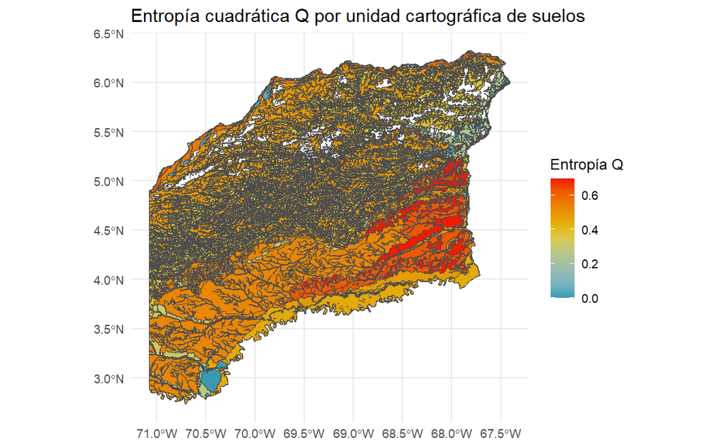

```r
# Unir los valores de Q con el objeto espacial
datos_sf_q <- datos_sf_wgs84 %>%
  left_join(Q_por_OBJECTID, by = "OBJECTID")

#Paleta de colores
pal <- wes_palette("Zissou1", 100, type = "continuous")

ggplot(datos_sf_q) +
  geom_sf(aes(fill = Q), color = "gray30") +
  scale_fill_gradientn(colours = pal, na.value = "white") +
  labs(
    title = "Entropía cuadrática Q por unidad cartográfica de suelos",
    fill = "Entropía Q"
  ) +
  theme_minimal()
```

Se crea el mosaico gráfico para exportar

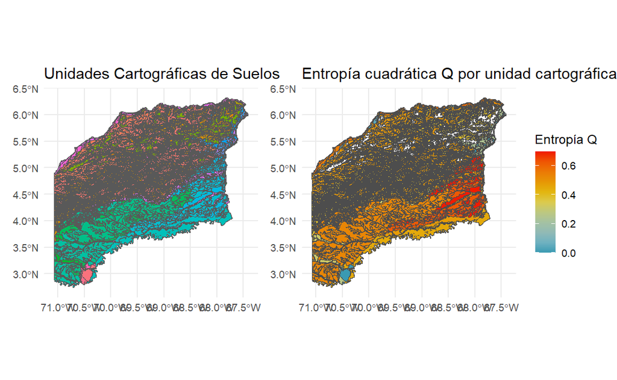

```r
plot_ucs_vichada + plot_rao_vichada
```

```r
# Funcion para exportar gráfica plot_mosaico_rao_vichada
```